# Caret / Recursive Partitioning

Ryan Guzalowski

5/16/17

## Exercise 1: caret/logistic regression (5 points)

Rebuild your logistic regression model from the previous week, this time using the `caret` package.

- Calculate the training or apparent performance of the model.
- Calculate an unbiased measure of performance
- Create a ROC Curve for your model

Show all work.

```r
YX <- readRDS( "YX.rds")
predictors <- c("dep_delay", "month", "air_time", "distance", "carrier", "lat.dest", "lon.dest")
response <- c("late")
yx <- subset(YX, select = c(response, predictors)) %>% sample_n(1000) %>% na.omit()
yx$carrier <- yx$carrier %>% as.factor()
yx$late <- yx$late %>% as.character()
yx$late[yx$late=="TRUE"] <- "late"
yx$late[yx$late=="FALSE"] <- "notLate"
yx$late <- yx$late %>% as.factor()
form <- late ~ dep_delay + month + air_time + distance + carrier + lat.dest + lon.dest

ctrlLD <- trainControl(method = "cv", number = 10,
                       savePredictions = TRUE,
                       classProbs = TRUE)

fitLD <- train(form, data = yx,
               method = "glm", family = "binomial",
               trControl = ctrlLD,
               na.action = na.omit)
### APPARENT PERFORMANCE ###
y_app <- yx$late
yhat_app <- predict(fitLD, data = yx)
accuracy_app <- sum(y_app == yhat_app)/length(y_app)
print(paste("Apparent accuracy of GLM fit: ", accuracy_app %>% round(4)))
```

```
## [1] "Apparent accuracy of GLM fit:  0.9391"
```

```r
### UNBIASED MEASURE OF PERFORMANCE ###
# uses 10 fold cross validation
summary(fitLD)
```

```
##
## Call:
## NULL
##
## Deviance Residuals:
##     Min       1Q   Median       3Q      Max
## -3.5792   0.0635   0.1593   0.2754   2.3545
##
## Coefficients:
##               Estimate Std. Error z value Pr(>|z|)
## (Intercept)    2.21847    3.43158   0.646   0.5180
## dep_delay     -0.13611    0.01087 -12.516  < 2e-16 ***
## month          0.01061    0.04001   0.265   0.7908
## air_time      -0.09748    0.01341  -7.267 3.67e-13 ***
## distance       0.01233    0.00225   5.480 4.26e-08 ***
## carrierAA     -0.20917    0.86066  -0.243   0.8080
## carrierB6     -0.04205    0.85104  -0.049   0.9606
## carrierDL      0.08612    0.84884   0.101   0.9192
## carrierEV      0.63220    0.83745   0.755   0.4503
## carrierF9     11.08213 1003.64432   0.011   0.9912
## carrierFL      0.15719    1.32576   0.119   0.9056
## carrierHA      7.05586 1455.39855   0.005   0.9961
## carrierMQ     -1.14501    0.84431  -1.356   0.1751
## carrierUA      0.37549    0.83979   0.447   0.6548
## carrierUS     -0.59571    0.90925  -0.655   0.5124
## carrierVX     -0.57498    1.48928  -0.386   0.6994
## carrierWN      1.76430    1.01324   1.741   0.0816 .
## carrierYV     -1.87154    2.56176  -0.731   0.4650
## lat.dest       0.02576    0.05334   0.483   0.6291
## lon.dest      -0.02368    0.07017  -0.338   0.7357
## ---
## Signif. codes:  0 '***' 0.001 '**' 0.01 '*' 0.05 '.' 0.1 ' ' 1
##
## (Dispersion parameter for binomial family taken to be 1)
##
##     Null deviance: 989.76  on 952  degrees of freedom
## Residual deviance: 339.42  on 933  degrees of freedom
## AIC: 379.42
##
## Number of Fisher Scoring iterations: 14
```

```r
print(fitLD)
```

```
## Generalized Linear Model
##
## 953 samples
##   7 predictor
##   2 classes: 'late', 'notLate'
##
## No pre-processing
## Resampling: Cross-Validated (10 fold)
## Summary of sample sizes: 857, 857, 858, 857, 858, 858, ...
## Resampling results:
##
##   Accuracy  Kappa
##   0.931875  0.7874635
```

```r
accuracy_cv <- fitLD$results$Accuracy
print(paste("Unbiased accuracy of GLM fit: ", accuracy_cv %>% round(4)))
```

```
## [1] "Unbiased accuracy of GLM fit:  0.9319"
```

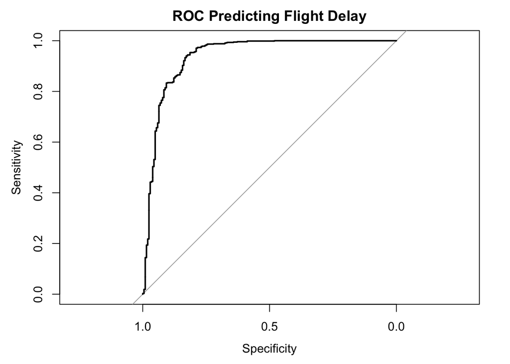

```r
### ROC CURVE ###
y_cv <- fitLD$pred$obs
yhat_cv <- fitLD$pred$late
rocCurve <- roc(y_cv, yhat_cv)
plot(rocCurve, main = "ROC Predicting Flight Delay")
```

```r
print(rocCurve)
```

```
##
## Call:
## roc.default(response = y_cv, predictor = yhat_cv)
##
## Data: yhat_cv in 204 controls (y_cv late) > 749 cases (y_cv notLate).
## Area under the curve: 0.9385
```

## Exercise 2: caret/rpart (5 points)

Using the `caret` and `rpart` packages, create a **classification** model for flight delays using your NYC FLight data. Your solution should include:

- The use of `caret` and `rpart` to train a model.
- An articulation of the the problem your are
- An naive model
- An unbiased calculation of the performance metric
- A plot of your model – (the actual tree; there are several ways to do this)
- A discussion of your model

Show and describe all work

ARTICULATION OF THE PROBLEM: We are trying to predict if a flight will be late or not. Classification tree splits the predictors at intelligent places so that at any end node of the decision tree you can determine if the flight is late or not.

DISCUSSION OF THE MODEL: The algo determined that the only predictor it would split was departure delay. This is exactly what I did for the naive model. The accuracy results were about the same. Overall, I do not think a CART is appropriate for this dataset as there is not much improvement over the naive model.

```r
### USE OF CARET/RPART TO TRAIN MODEL ###
ctrlCART <- trainControl(method = "cv", number = 10,
                         savePredictions = TRUE,
                         classProbs = TRUE)
fitCART <- train(form, data = yx,
                method = "rpart",
                trControl = ctrlCART)

### NAIVE MODEL ###
# if flight dep_delay is >20 min, then arrival delay will be >20 min (defined late)
y_naive <- yx$late
yhat_naive <- rep(0, y_naive %>% length())
yhat_naive <- ifelse(yx$dep_delay>20, "late", "notLate")
accuracy_naive <- sum(y_naive == yhat_naive)/length(y_naive)
print(paste("Accuracy of naive model: ", accuracy_naive %>% round(4)))
```

```
## [1] "Accuracy of naive model:  0.9108"
```

```r
### UNBIASED PERFORMANCE METRIC ###
# uses 10 fold cross validation
accuracy_cart <- fitCART$results$Accuracy[2]
print(paste("Accuracy of CART model: ", accuracy_cart %>% round(4)))
```

```
## [1] "Accuracy of CART model:  0.9235"
```

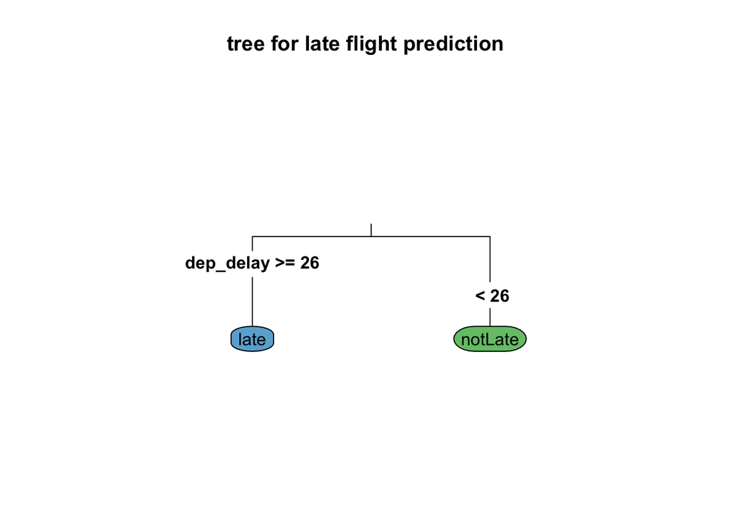

```r
### PLOT OF THE MODEL ###
fitCARTfinalModel <- fitCART$finalModel
rpart.plot(fitCARTfinalModel, type = 3, extra = 0,
           main = "tree for late flight prediction")
```

### Questions:

- Discuss the difference between the models and why you would use one model over the other?

Use classification model if your predictors have binomial or other clustered distributions. That way, the CART algo will have an easier time finding places to split. Use logistic regression if your predictors are normally distributed.

- How might you produce an ROC type curve for the *rpart* model?

The ROC “curve” will be only a point on the sensitivity/selectivity graph because the predictors are discrete. So you will have a only two values for selectivity/sensitivity of the model. You could connect these points to the (0,1) and (1,0) points to get your “curve”. Then find area under curve like normal and you have a metric for comparing the goodness of different models.